# EDA of Google Play Store

Shivam Saini

```r
library(tidyverse)
library(lubridate)
library(gridExtra)
```

Note: The data set contains a sample of around 10K apps scraped from Google Play Store. Original source: https://www.kaggle.com/lava18/google-play-store-apps

Let’s load the data set

```r
gplay<- read_csv("googleplaystore.csv")
dim(gplay)
```

```
## [1] 10841    13
```

```r
head(gplay)
```

```
## # A tibble: 6 x 13
##   App   Category Rating Reviews Size  Installs Type  Price `Content Rating`
##   <chr> <chr>     <dbl>   <dbl> <chr> <chr>    <chr> <chr> <chr>
## 1 Phot… ART_AND…    4.1     159 19M   10,000+  Free  0     Everyone
## 2 Colo… ART_AND…    3.9     967 14M   500,000+ Free  0     Everyone
## 3 U La… ART_AND…    4.7   87510 8.7M  5,000,0… Free  0     Everyone
## 4 Sket… ART_AND…    4.5  215644 25M   50,000,… Free  0     Teen
## 5 Pixe… ART_AND…    4.3     967 2.8M  100,000+ Free  0     Everyone
## 6 Pape… ART_AND…    4.4     167 5.6M  50,000+  Free  0     Everyone
## # … with 4 more variables: Genres <chr>, `Last Updated` <chr>, `Current
## #   Ver` <chr>, `Android Ver` <chr>
```

- There are 10841 apps in this sample of Play Store Apps.
- The values in column “Installs”, “Price” and “Size” are stored as character and need to be changed to numeric.
- “Current Ver” column contains “Varies with device”.
- “Last Updated” needs to be changed to Date type.
- “Category”, “Content Rating” and “Type” should be stored as factors.

```r
summary(gplay)
```

```
##      App              Category             Rating          Reviews
##  Length:10841       Length:10841       Min.   : 1.000   Min.   :       0
##  Class :character   Class :character   1st Qu.: 4.000   1st Qu.:      38
##  Mode  :character   Mode  :character   Median : 4.300   Median :    2094
##                                        Mean   : 4.193   Mean   :  444153
##                                        3rd Qu.: 4.500   3rd Qu.:   54776
##                                        Max.   :19.000   Max.   :78158306
##                                        NA's   :1474     NA's   :1
##      Size             Installs             Type
##  Length:10841       Length:10841       Length:10841
##  Class :character   Class :character   Class :character
##  Mode  :character   Mode  :character   Mode  :character
##
##
##
##
##     Price           Content Rating        Genres
##  Length:10841       Length:10841       Length:10841
##  Class :character   Class :character   Class :character
##  Mode  :character   Mode  :character   Mode  :character
##
##
##
##
##  Last Updated       Current Ver        Android Ver
##  Length:10841       Length:10841       Length:10841
##  Class :character   Class :character   Class :character
##  Mode  :character   Mode  :character   Mode  :character
##
##
##
##
```

- Multiple NAs are present in “Rating” and “Reviews” columns. *“Rating” column has max. value 19 which can’t be possible as Google Play store rates app on a 0-5 scale.

```r
cat('no. of duplicated rows: ',sum(duplicated(gplay$App)))
```

```
## no. of duplicated rows:  1181
```

```r
#remove duplicates
gplay<- distinct(gplay)
gplay<- gplay[-c(which(duplicated(gplay$App))),]

#convert variable names to lower case and remove spaces
names(gplay) <- tolower(names(gplay))
names(gplay) <- str_replace_all(names(gplay), pattern= " ", replacement = "_")

#correct rating column
gplay$rating<- ifelse(gplay$rating<=5, gplay$rating, NA)

#converting categories to factor
gplay$category <- as.factor(gplay$category)
gplay$content_rating<- as.factor(gplay$content_rating)
```

```r
unique(gplay$type)
```

```
## [1] "Free" "Paid" "NaN"  "0"
```

```r
gplay[gplay$type %in% c('NaN', '0'), ]
```

```
## # A tibble: 2 x 13
##   app   category rating reviews size  installs type  price content_rating
##   <chr> <fct>     <dbl>   <dbl> <chr> <chr>    <chr> <chr> <fct>
## 1 Comm… FAMILY       NA       0 Vari… 0        NaN   0     Everyone 10+
## 2 Life… 1.9          NA      NA 1,00… Free     0     Ever… <NA>
## # … with 4 more variables: genres <chr>, last_updated <chr>,
## #   current_ver <chr>, android_ver <chr>
```

both these rows have multiple missing values so i am dropping these rows.

```r
gplay<- gplay[!gplay$type %in% c('NaN', '0'), ]

#change type to factor
gplay$type <- as.factor(gplay$type)

#formatting dates
gplay$last_updated <- mdy(gplay$last_updated)

#removing version and genre.
gplay$current_ver <- NULL
gplay$genres<- NULL
```

```r
#converting size, installs and price to numbers
gplay$installs<- parse_number(gplay$installs)
gplay$size<- parse_number(gplay$size)
gplay$price<- parse_number(gplay$price)
```

```r
unique(gplay$android_ver)
```

```
##  [1] "4.0.3 and up"       "4.2 and up"         "4.4 and up"
##  [4] "2.3 and up"         "3.0 and up"         "4.1 and up"
##  [7] "4.0 and up"         "2.3.3 and up"       "Varies with device"
## [10] "2.2 and up"         "5.0 and up"         "6.0 and up"
## [13] "1.6 and up"         "1.5 and up"         "2.1 and up"
## [16] "7.0 and up"         "5.1 and up"         "4.3 and up"
## [19] "4.0.3 - 7.1.1"      "2.0 and up"         "3.2 and up"
## [22] "4.4W and up"        "7.1 and up"         "7.0 - 7.1.1"
## [25] "8.0 and up"         "5.0 - 8.0"          "3.1 and up"
## [28] "2.0.1 and up"       "4.1 - 7.1.1"        "NaN"
## [31] "5.0 - 6.0"          "1.0 and up"         "2.2 - 7.1.1"
## [34] "5.0 - 7.1.1"
```

```r
gplay[gplay$android_ver %in% c('Varies with device', 'NaN'), "android_ver"] <- NA
```

```r
summary(gplay)
```

```
##      app                       category        rating
##  Length:9658        FAMILY         :1831   Min.   :1.000
##  Class :character   GAME           : 959   1st Qu.:4.000
##  Mode  :character   TOOLS          : 827   Median :4.300
##                     BUSINESS       : 420   Mean   :4.173
##                     MEDICAL        : 395   3rd Qu.:4.500
##                     PERSONALIZATION: 376   Max.   :5.000
##                     (Other)        :4850   NA's   :1462
##     reviews              size            installs           type
##  Min.   :       0   Min.   :   1.00   Min.   :0.000e+00   Free:8902
##  1st Qu.:      25   1st Qu.:   5.30   1st Qu.:1.000e+03   Paid: 756
##  Median :     967   Median :  14.00   Median :1.000e+05
##  Mean   :  216615   Mean   :  37.13   Mean   :7.778e+06
##  3rd Qu.:   29408   3rd Qu.:  32.00   3rd Qu.:1.000e+06
##  Max.   :78158306   Max.   :1020.00   Max.   :1.000e+09
##                     NA's   :1226
##      price                 content_rating  last_updated
##  Min.   :  0.000   Adults only 18+:   3   Min.   :2010-05-21
##  1st Qu.:  0.000   Everyone       :7903   1st Qu.:2017-08-05
##  Median :  0.000   Everyone 10+   : 321   Median :2018-05-04
##  Mean   :  1.099   Mature 17+     : 393   Mean   :2017-10-30
##  3rd Qu.:  0.000   Teen           :1036   3rd Qu.:2018-07-17
##  Max.   :400.000   Unrated        :   2   Max.   :2018-08-08
##
##  android_ver
##  Length:9658
##  Class :character
##  Mode  :character
##
##
##
##
```

There are many NA values in data set.

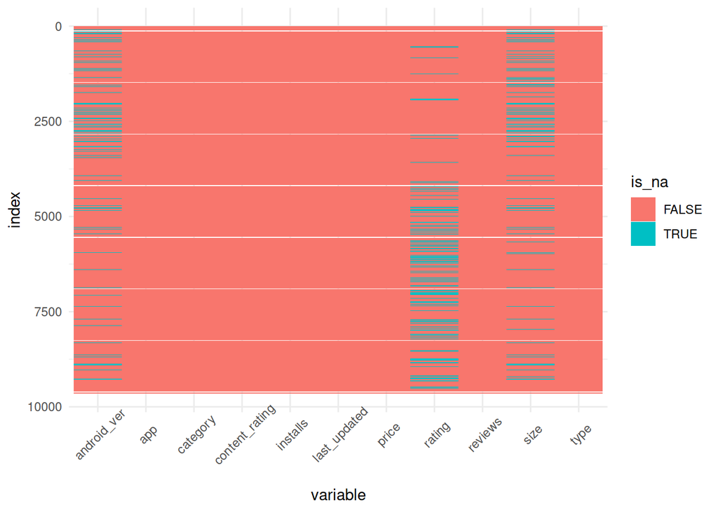

```r
is.na(gplay) %>%
    as_tibble %>%
    mutate(index = row_number()) %>%
    gather(key= variable, value = is_na , 1:11) %>%
    ggplot() +
    geom_tile(aes(x= variable, y= index, fill=is_na)) +
    theme_minimal() +
    theme(axis.text.x= element_text(angle=45, vjust = 0.8)) +
    scale_y_reverse() +
    labs('Missing values by position')
```

I am going to remove the android version column because it has many NA values and is already very poorly defined.

```r
#remove android version
gplay$android_ver<- NULL
```

For rating and size I will use the average rating and size of the category to fill missing values.

```r
avg_by_cat<- gplay %>%
                select(rating, size, category) %>%
                group_by(category) %>%
                summarise( avg_rating=mean(rating, na.rm= TRUE) , avg_size= mean(size, na.rm= TRUE))
avg_by_cat
```

```
## # A tibble: 33 x 3
##    category            avg_rating avg_size
##    <fct>                    <dbl>    <dbl>
##  1 ART_AND_DESIGN            4.36     12.4
##  2 AUTO_AND_VEHICLES         4.19     34.5
##  3 BEAUTY                    4.28     13.8
##  4 BOOKS_AND_REFERENCE       4.34     40.6
##  5 BUSINESS                  4.10     26.8
##  6 COMICS                    4.18     35.3
##  7 COMMUNICATION             4.12     59.2
##  8 DATING                    3.97     15.8
##  9 EDUCATION                 4.36     31.2
## 10 ENTERTAINMENT             4.14     23.0
## # … with 23 more rows
```

```r
for(i in 1: nrow(avg_by_cat) ) {
    gplay[is.na(gplay$rating) & (gplay$category %in% avg_by_cat$category[i]), "rating"]<- avg_by_cat[i,2]
}

for(i in 1: nrow(avg_by_cat) ) {
    gplay[is.na(gplay$size) & (gplay$category %in% avg_by_cat$category[i]), "size"]<- avg_by_cat[i,3]
}
```

```r
summary(gplay)
```

```
##      app                       category        rating
##  Length:9658        FAMILY         :1831   Min.   :1.000
##  Class :character   GAME           : 959   1st Qu.:4.000
##  Mode  :character   TOOLS          : 827   Median :4.200
##                     BUSINESS       : 420   Mean   :4.172
##                     MEDICAL        : 395   3rd Qu.:4.500
##                     PERSONALIZATION: 376   Max.   :5.000
##                     (Other)        :4850
##     reviews              size            installs           type
##  Min.   :       0   Min.   :   1.00   Min.   :0.000e+00   Free:8902
##  1st Qu.:      25   1st Qu.:   6.20   1st Qu.:1.000e+03   Paid: 756
##  Median :     967   Median :  17.00   Median :1.000e+05
##  Mean   :  216615   Mean   :  36.78   Mean   :7.778e+06
##  3rd Qu.:   29408   3rd Qu.:  35.92   3rd Qu.:1.000e+06
##  Max.   :78158306   Max.   :1020.00   Max.   :1.000e+09
##
##      price                 content_rating  last_updated
##  Min.   :  0.000   Adults only 18+:   3   Min.   :2010-05-21
##  1st Qu.:  0.000   Everyone       :7903   1st Qu.:2017-08-05
##  Median :  0.000   Everyone 10+   : 321   Median :2018-05-04
##  Mean   :  1.099   Mature 17+     : 393   Mean   :2017-10-30
##  3rd Qu.:  0.000   Teen           :1036   3rd Qu.:2018-07-17
##  Max.   :400.000   Unrated        :   2   Max.   :2018-08-08
##
```

## VISUALISATIONS

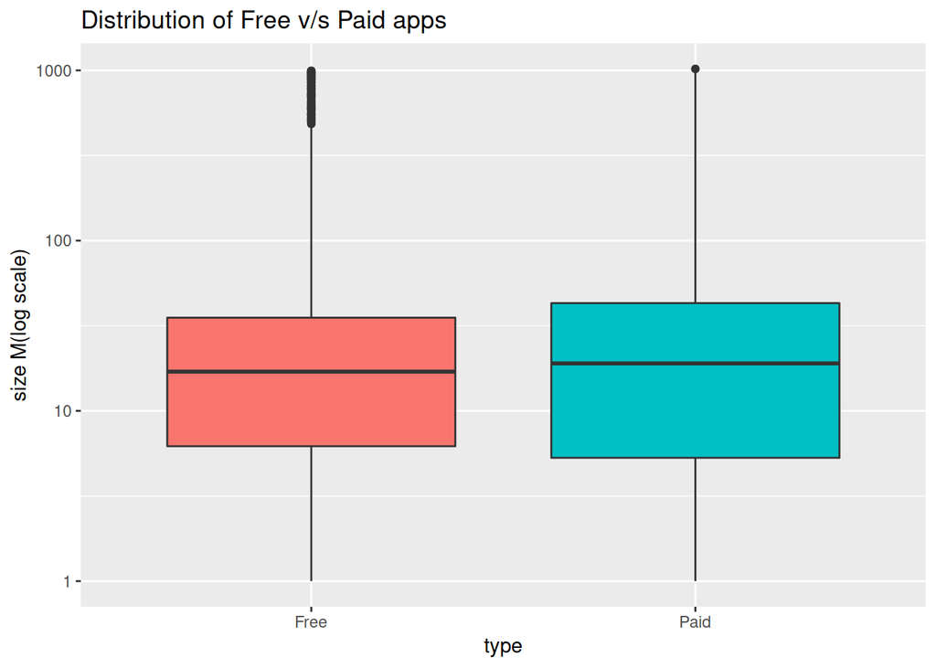

```r
gplay %>%
    select(size, type) %>%
    ggplot() +
    geom_boxplot(aes(x =type, size, fill = type), show.legend = F) +
    scale_y_continuous(trans= 'log10') +
    labs(y='size M(log scale)', title= 'Distribution of Free v/s Paid apps')
```

- Free and paid both applications have similar sized distributions. However, there are more free apps of extremely large size than paid apps.

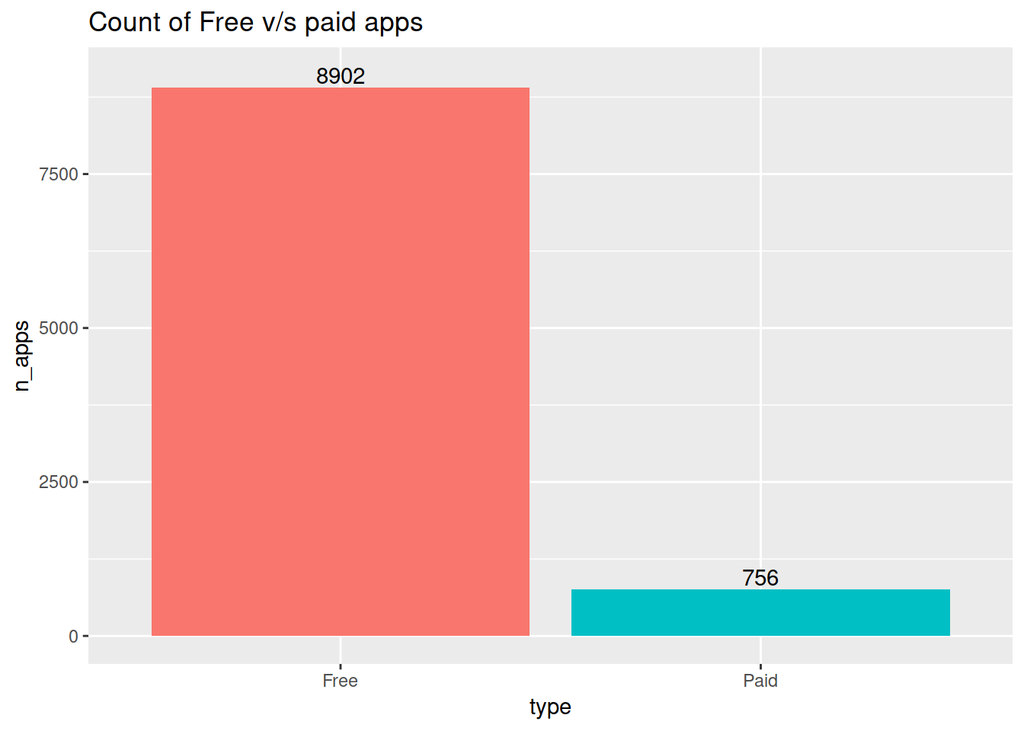

```r
num_apps<- gplay%>%
    select(type) %>%
    group_by(type) %>%
    summarise(n_apps= n())

ggplot(num_apps) +
    geom_bar(stat='identity', aes(y= n_apps, x= type, fill = type), show.legend=F) +
    geom_text(aes(y= n_apps+ 200, x= type, label= n_apps))  +
    labs(title='Count of Free v/s paid apps')
```

- There are more free apps on Google Play Store than Paid apps.

Let’s see how many apps are there on Play Store in each category.

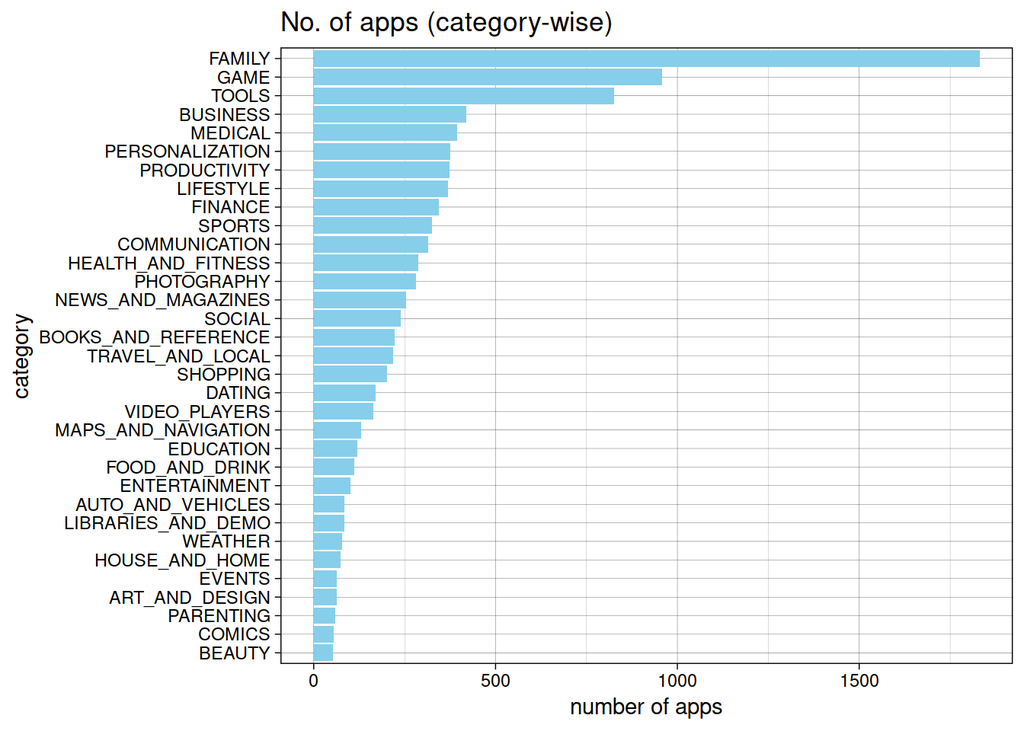

```r
gplay %>%
 select(category) %>%
 group_by(category) %>%
      summarise(app_num = n()) %>%
 ggplot() + geom_bar(stat ='identity' , aes(y = app_num, x = reorder(category, app_num)), fill = 'skyblue') +
 coord_flip() + theme(legend.position = 'none') + labs(x= 'category',y= 'number of apps') + theme_linedraw() +
labs(title= 'No. of apps (category-wise)')
```

- Family apps leads the list with more than 1500 apps.
- The proportion of Games, tools, and family apps is much more than any other category.

Let’s see how apps compare by price.

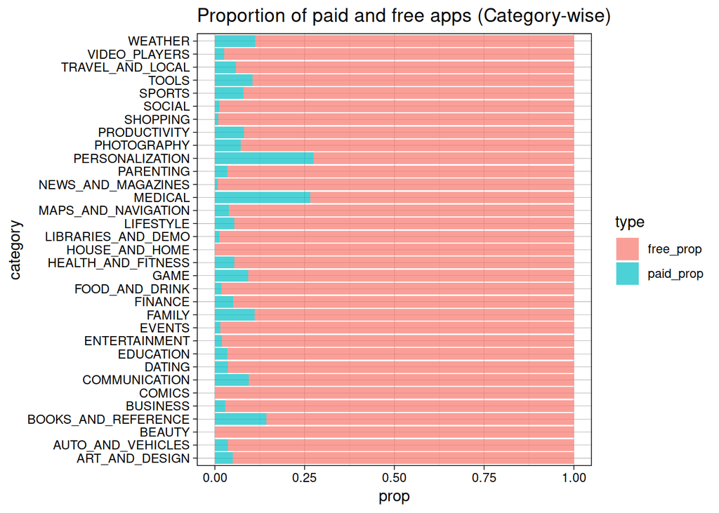

```r
gplay %>%
 select(category, type) %>%
 group_by(category, type) %>%
 summarise(app_num = n())  %>%
 spread(type, app_num, fill =0) %>%
 mutate(paid_prop= Paid/Free,
       free_prop =1-paid_prop) %>%
 select(-Free, -Paid)%>%
 gather(type, prop, 2,3) %>%
 ggplot() + geom_bar(stat='identity', aes(y= prop, x= category, fill= type) ,alpha =0.7) + coord_flip()  +
 theme_linedraw() +
 labs(title ='Proportion of paid and free apps (Category-wise)')
```

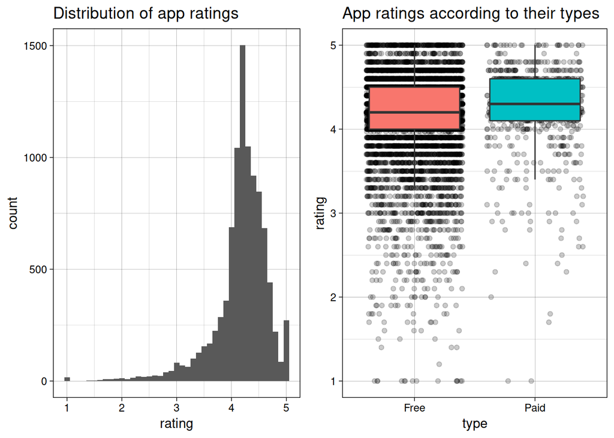

```r
p1<- gplay %>%
    select(type, rating) %>%
    ggplot() +
    geom_histogram(aes(rating), binwidth =0.1)  +
    ggtitle("Distribution of app ratings") +theme_linedraw()

p2<- gplay %>%
    select(type, rating) %>%
    ggplot() +
     geom_jitter(aes(x= type , y= rating), alpha =0.2)+
    geom_boxplot(aes(x = type , y= rating, fill = type), show.legend= F, outlier.shape=NA) +
    ggtitle("App ratings according to their types") + theme_linedraw()

grid.arrange(p1, p2, ncol = 2)
```

- The distribution of app rating is left skewed implying most of the apps provide satisfactory experience to users.
- Paid apps have higher ratings compared to Free apps.

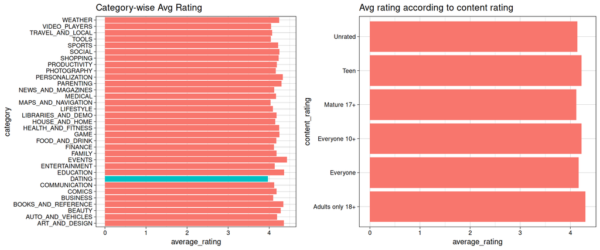

```r
p3<- gplay %>%
    select(category, rating) %>%
    group_by(category) %>%
    summarise(average_rating= mean(rating)) %>%
    ggplot() +
    geom_bar(stat= 'identity', aes(x= category, y= average_rating, fill =average_rating<=4),show.legend= F) +
    coord_flip() +theme_linedraw() + labs(title='Category-wise Avg Rating')
p4<- gplay%>%
    select(content_rating, rating) %>%
    group_by(content_rating) %>%
    summarise(average_rating= mean(rating)) %>%
    ggplot() +
    geom_bar(stat= 'identity', aes(x= content_rating, y= average_rating, fill =average_rating<=4),show.legend= F) +
    coord_flip() +theme_linedraw() + labs(title= 'Avg rating according to content rating')

grid.arrange(p3, p4, ncol = 2)
```

- All of the categories except Dating have average rating over 4.

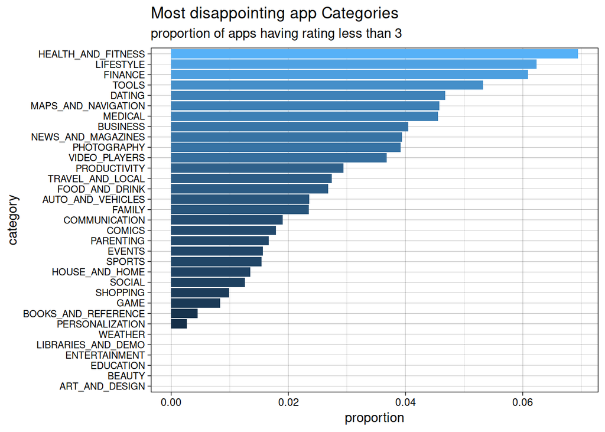

```r
gplay %>%
 select(category, rating) %>%
 mutate(disappointing = rating<3) %>%
 group_by(category) %>%
 summarise(total_num = n(), num_dis = sum(disappointing)) %>%
 mutate(prop_dis= num_dis/total_num) %>%
 select(category, prop_dis) %>%
 ggplot() +
 geom_bar(stat='identity', aes(x= reorder(category, prop_dis), y= prop_dis, fill = prop_dis), show.legend=F) +
 coord_flip()+ theme_linedraw()+ theme(axis.text.y = element_text(size= 8))+
 labs(title = 'Most disappointing app Categories', subtitle='proportion of apps having rating less than 3',
           x= 'category', y= 'proportion')
```

- Here I’ve chosen the number of apps having rating less than 3 as disappointing apps.

The representation of categories of app is not similar and hence it is not right to compare the categories based on the absolute number of disappointing apps. I’ve decided to use the category-wise proportion of disappointing apps to compare the categories.

- All the categories have less than ten percent of disappointing apps.
- Interestingly, the category Health and Fitness is most disappointing possibly because users generally have higher expectations from these kind of apps and nonfullfillment of those expectations leads to disappointment and lower reviews.

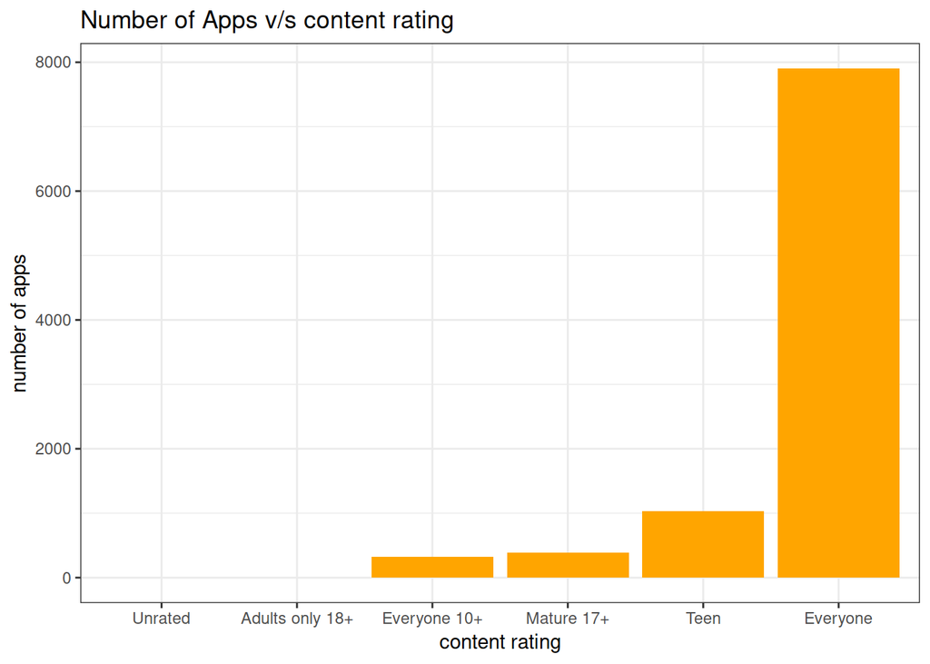

```r
gplay %>%
    select(content_rating) %>%
    group_by(content_rating) %>%
    summarise(number_of_apps = n()) %>%
    ggplot()+
    geom_bar(stat= 'identity',aes(x= reorder(content_rating, number_of_apps), y= number_of_apps), fill= 'orange') +
    labs(title= 'Number of Apps v/s content rating', x= 'content rating' , y= 'number of apps') +theme_bw()
```

- Most of the apps are focused toward the audience of all the ages, in line with our previous result which showed the family apps are the leading category of apps on play store.
- Teen apps takes the second position, most probably these are gaming and social media applications.

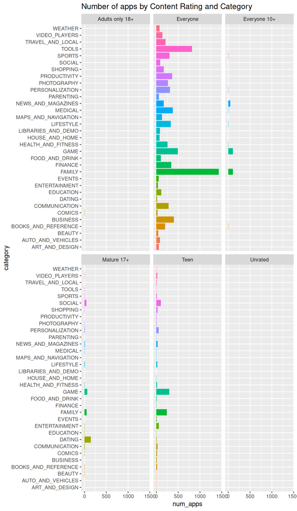

```r
gplay %>%
    select(category, content_rating) %>%
    group_by(content_rating, category) %>%
    summarise( num_apps = n()) %>%
    ggplot() +
    geom_bar(stat= 'identity', aes(x= category, y= num_apps, fill = category), show.legend= F) +
    coord_flip() +
    facet_wrap(~content_rating) +
    labs(title='Number of apps by Content Rating and Category')
```

- As expected, most of the apps rated Everyone are family apps and tools. Similar trend can be seen in 10+ rated apps.
- Games, Family and Social media apps constitute a majority of teen apps. This indicates most of the social media apps and games are intended for Teenage users.
- Dating apps lead the Mature category.

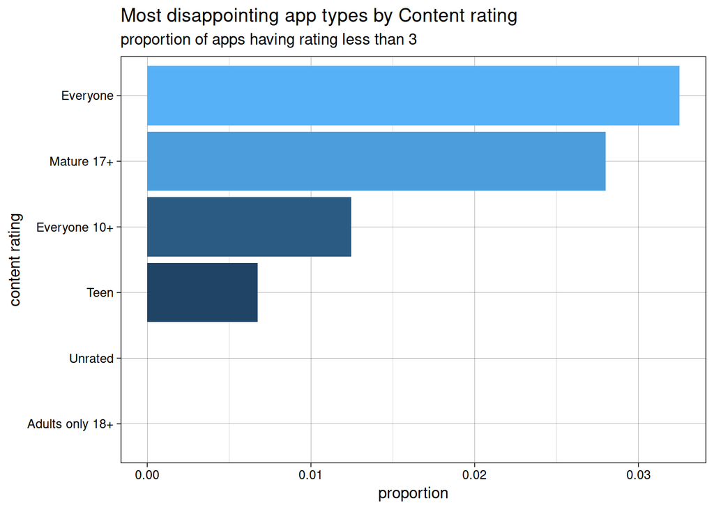

```r
gplay %>%
 select(content_rating, rating) %>%
 mutate(disappointing = rating<3) %>%
 group_by(content_rating) %>%
 summarise(total_num = n(), num_dis = sum(disappointing)) %>%
 mutate(prop_dis= num_dis/total_num) %>%
 select(content_rating, prop_dis) %>%
 ggplot() +
 geom_bar(stat='identity', aes(x= reorder(content_rating, prop_dis), y= prop_dis, fill = prop_dis), show.legend=F) +
 coord_flip()+ theme_linedraw()+
 labs(title = 'Most disappointing app types by Content rating', subtitle='proportion of apps having rating less than 3',
           x= 'content rating', y= 'proportion')
```

- Apps rated for mature users are 2nd most disappointing app types.

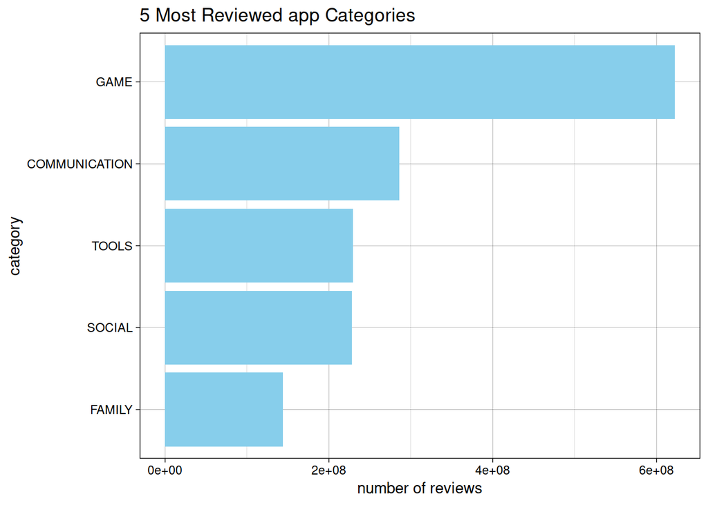

```r
gplay %>%
 select(category, reviews) %>%
 group_by(category) %>%
 summarise(review_num = sum(reviews)) %>%
 top_n(5, review_num ) %>%
 ggplot() +
 geom_bar(stat ='identity' , aes(y = review_num, x = reorder(category, review_num)), fill = 'skyblue') +
 coord_flip() +
 theme(legend.position = 'none') +
 labs(title='5 Most Reviewed app Categories',x= 'category',y= 'number of reviews') + theme_linedraw()
```

- Users tend to review Gaming apps more than any other category. These apps are intended for teen population and teens are more likely to rate and review apps.

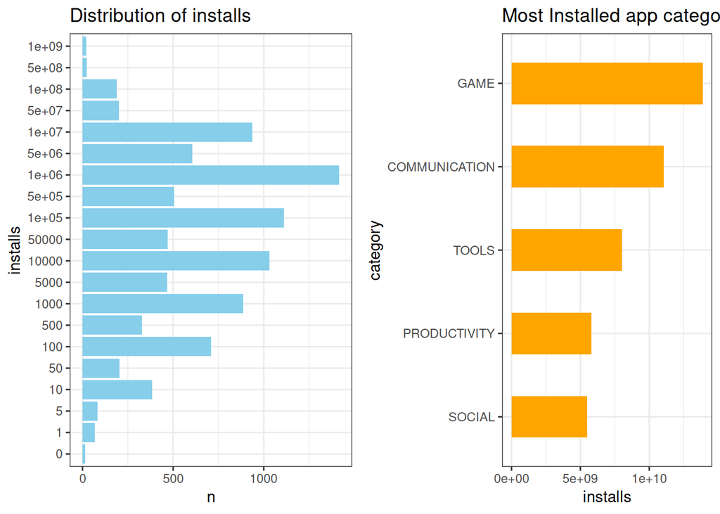

```r
 p5<- gplay %>%
    select(installs) %>%
    mutate(installs= as.factor(installs)) %>%
    group_by(installs) %>%
    summarise(n= n()) %>%
    ggplot()+
    geom_bar(stat='identity',aes(x=installs , y=n), fill = 'skyblue')  + theme_bw() +
    coord_flip() +
    labs(title='Distribution of installs', x= 'installs')

p6<- gplay %>%
    select(installs, category) %>%
    group_by(category) %>%
    summarise(installs = sum(installs)) %>%
    top_n(5, installs) %>%
    ggplot() +
    geom_bar(stat= 'identity', aes(x= reorder(category, installs), y= installs), fill ='orange', width =0.5) + coord_flip()+
    theme_bw() +
    labs(title='Most Installed app category', x= 'category'  )

grid.arrange(p5, p6, ncol=2)
```

- Game and Communication apps are the most downloaded app categories.

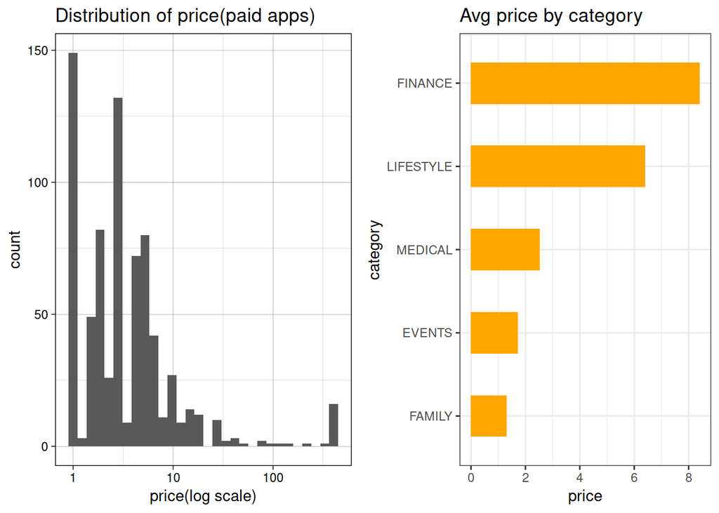

```r
p7<- gplay %>%
    select(price) %>%
    filter(price !=0) %>%
    ggplot()+
    geom_histogram(aes(x=price))+scale_x_log10() +theme_linedraw() +
    labs(title='Distribution of price(paid apps)', x= 'price(log scale)')

p8<- gplay %>%
    select(price, category) %>%
    group_by(category) %>%
    summarise(price = mean(price)) %>%
    top_n(5, price) %>%
    ggplot() +
    geom_bar(stat= 'identity', aes(x= reorder(category, price), y= price), fill ='orange', width =0.5) + coord_flip()+
    theme_bw() +
    labs(title='Avg price by category', x= 'category'  )
grid.arrange(p7, p8, ncol=2)
```

- Most of the paid apps on Play Store cost less than $10.
- Finance apps have higher average price than other apps.

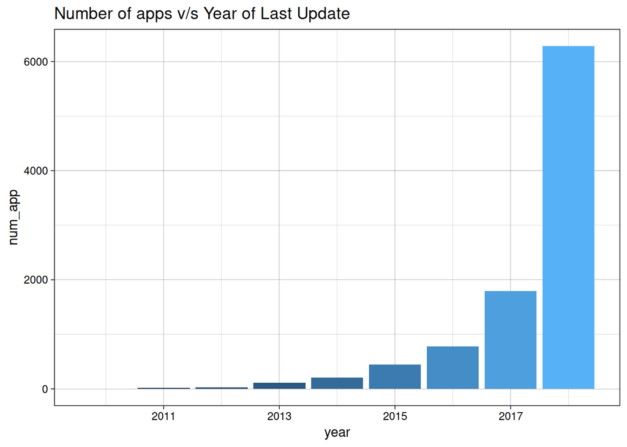

```r
gplay %>%
    select(last_updated) %>%
    group_by(year=year(last_updated)) %>%
    summarise(num_app= n()) %>%
    ggplot()+
    geom_bar(stat='identity', aes(x= year, y = num_app ,fill = year), show.legend=F) +theme_linedraw() +
    labs(title= 'Number of apps v/s Year of Last Update')
```

- Most of the apps were updated in the year 2018.

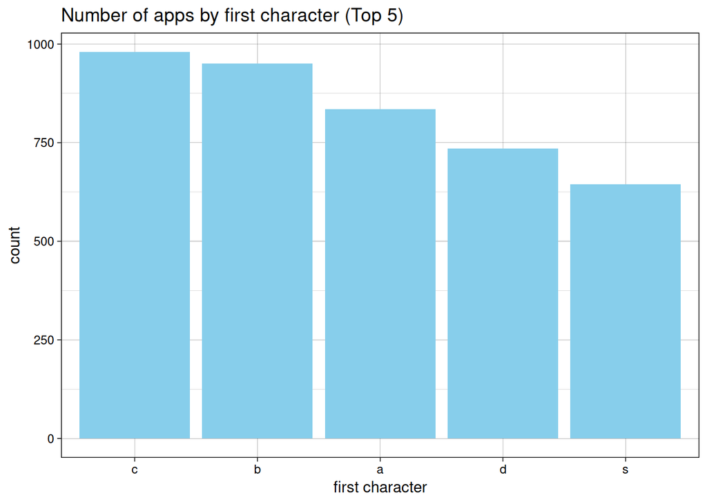

```r
first_char<-str_sub(gplay$app, start=1, end = 1)

first_char<- as.factor(tolower(first_char) ) %>%
    tibble(char=.)

first_char %>%
  group_by(char) %>%
  summarise(count= n()) %>%
  arrange(desc(count)) %>% top_n(5) %>%
  ggplot() +
  geom_bar(stat='identity', aes(x= reorder(char, -count), y= count), fill ='skyblue') +theme_linedraw() +
  labs(title= 'Number of apps by first character (Top 5)', x= 'first character')
```

- The top 4 characters are the first 4 alphabets. App developers generally, try to name their apps in this way to make their app appear higher on the list when sorted by alphabetical order.

We began with cleaning the data, and then collected multiple insights about data like most disappointing apps, most downloaded categories, teen’s choice and more while exploring the data. Let’s end this by listing the 5 most popular apps.

```r
gplay %>%
  filter(installs>=1e09) %>%
  select(app, category, reviews, type, content_rating) %>%
  arrange(desc(reviews)) %>%
  top_n(n = 5, reviews)
```

```
## # A tibble: 5 x 5
##   app                             category     reviews type  content_rating
##   <chr>                           <fct>          <dbl> <fct> <fct>
## 1 Facebook                        SOCIAL        7.82e7 Free  Teen
## 2 WhatsApp Messenger              COMMUNICATI…  6.91e7 Free  Everyone
## 3 Instagram                       SOCIAL        6.66e7 Free  Teen
## 4 Messenger – Text and Video Cha… COMMUNICATI…  5.66e7 Free  Everyone
## 5 Subway Surfers                  GAME          2.77e7 Free  Everyone 10+
```

- Interestingly 4 out of these 5 apps are owned by Facebook Inc.